# Non-psychometric MLE

Olsson et al.

07/11/2020

Non-psychometric MLE chromatic background.

## Load Package for Mixed-Effects Modelling

```r
library('readr')
library('boot')
library('lme4')
library('MASS')
library('emmeans')
```

Read in data.

```r
col.dta <- read_delim('colour_discriminate_short_format.txt', delim='\t')
data <- col.dta
data$stimuli <- factor(data$stimuli)
data$target <- with(data, ifelse(background == stimuli, 'same', 'diff'))
data$target <- as.factor(data$target)
data$background <- factor(data$background)
data$ind <- factor(data$ind)
data$batch <- as.factor(data$batch)
data$chick <- paste0(data$ind, data$batch)
```

# Useful Functions

```r
resplot <- function(mod){
#are residuals normally distributed
hist(residuals(mod), prob = T, xlab = formula(mod), main = paste('Residuals for',(formula(mod)[3])))
lines(density(residuals(mod)), col = 'red')
lines(seq(min(residuals(mod)),max(residuals(mod)), length.out = 10^3), dnorm(seq(min(residuals(mod)),max(residuals(mod)), length.out = 10^3), 0, sd(residuals(mod))), col = 'blue')
legend('topright', legend = c('kernel density', 'fitted normal'), lty = 1, col = c('red', 'blue'))
boxplot(residuals(mod),
        add = T, axes = F, horizontal = T, cex = 0.5, outline = T, border = rgb(0,0.1,0,0.7), at = par('yaxp')[2]*0.1,
        pars = list(boxwex = par('yaxp')[2]*0.3, staplewex = par('yaxp')[2]*0.5, outwex = par('yaxp')[2]*0.05))#
}
```

## Fit Logistic Regression

Logistic regression fits a relationship between a binomial variable (yes|no, correct|incorrect, present|absent, 1|0) and any other predictor variable. Variance in binomial variable is constrained by the fact that there cannot be > 100% 1s or 0s in a dataset, so relationships always follows an “S” curve. Fit a mixed-effects (both controlled [‘fixed’] and unpredictable [‘random’] effects) logistic regression predicting ‘response’ (a correct or incorrect) and taking into account different intercepts (starting biases: “…1|ind”) and slopes (learning rates: “(Colour.difference-1|…”) of different inds, using the Generlized Linear Mixed Effects Regression (glmer) command

**N.B. There are not enough observations to estimate random effects of chick** **and batch across Colour.difference:target:background**

As it happens, batches are shared across backgrounds whereas chicks are unique to each condition. It might make more sense to look at random effects of chick on colour difference alone.

```r
nonpsych1 <- glmer(cbind(corr,incorr)~Colour.difference*background*target*sex +
                     (1+Colour.difference|chick)+
                     (1+Colour.difference*background|batch),
                   data = data, family = binomial(link = 'logit'))
```

Needs a little help converging, increase tolerance.

```r
print(.Machine$double.eps * 10^8)
```

```
## [1] 2.220446e-08
```

```r
nonpsych2 <- glmer(cbind(corr,incorr)~Colour.difference*background*target*sex +
                     (1+Colour.difference|chick)+
                     (1+Colour.difference*background|batch),
                   data = data, family = binomial(link = 'logit'),
                   control = glmerControl(tol = .Machine$double.eps * 10^8))
```

Fit a logistic regression using no information about experience, but controlling for the same random effects, as a test for an effect of experience on response (learning)

```r
nonpsych0 <- glmer(cbind(corr,incorr)~1 + (1|chick)+ (1|batch),
                   data = data, family = binomial(link = 'logit'))
```

Compare the variance in the data explained by experience

```r
anova(nonpsych0, nonpsych1, nonpsych2, test = 'Chisq')
```

```
## Data: data
## Models:
## nonpsych0: cbind(corr, incorr) ~ 1 + (1 | chick) + (1 | batch)
## nonpsych1: cbind(corr, incorr) ~ Colour.difference * background * target *
## nonpsych1:     sex + (1 + Colour.difference | chick) + (1 + Colour.difference *
## nonpsych1:     background | batch)
## nonpsych2: cbind(corr, incorr) ~ Colour.difference * background * target *
## nonpsych2:     sex + (1 + Colour.difference | chick) + (1 + Colour.difference *
## nonpsych2:     background | batch)
##           npar    AIC    BIC  logLik deviance  Chisq Df Pr(>Chisq)
## nonpsych0    3 1941.5 1950.8 -967.74  1935.47
## nonpsych1   29 1001.9 1091.8 -471.93   943.86 991.61 26     <2e-16 ***
## nonpsych2   29 1001.9 1091.8 -471.93   943.86   0.00  0          1
## ---
## Signif. codes:  0 '***' 0.001 '**' 0.01 '*' 0.05 '.' 0.1 ' ' 1
```

The model taking experience into account deviates less from the data recorded (there is an effect of experience).

```r
anova(nonpsych0, nonpsych2, test = 'Chisq')
```

```
## Data: data
## Models:
## nonpsych0: cbind(corr, incorr) ~ 1 + (1 | chick) + (1 | batch)
## nonpsych2: cbind(corr, incorr) ~ Colour.difference * background * target *
## nonpsych2:     sex + (1 + Colour.difference | chick) + (1 + Colour.difference *
## nonpsych2:     background | batch)
##           npar    AIC    BIC  logLik deviance  Chisq Df Pr(>Chisq)
## nonpsych0    3 1941.5 1950.8 -967.74  1935.47
## nonpsych2   29 1001.9 1091.8 -471.93   943.86 991.61 26  < 2.2e-16 ***
## ---
## Signif. codes:  0 '***' 0.001 '**' 0.01 '*' 0.05 '.' 0.1 ' ' 1
```

For more complex models, Akaike Information Criteria (AIC) may be compared.

```r
AIC(nonpsych0, nonpsych1, nonpsych2)
```

```
##           df      AIC
## nonpsych0  3 1941.473
## nonpsych1 29 1001.862
## nonpsych2 29 1001.863
```

The model with fixed effects has lower AIC, indicating a better fit

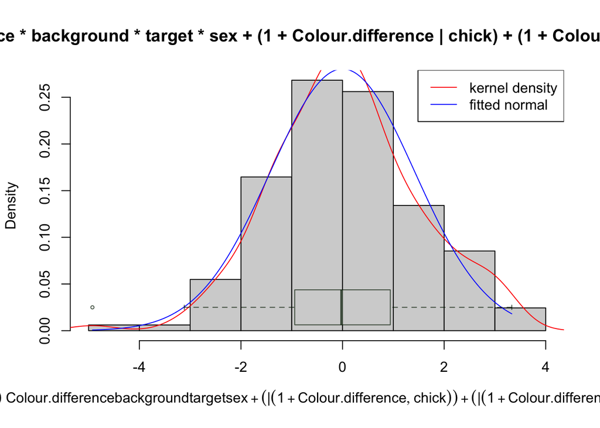

```r
resplot(nonpsych2)#looks good
```

```r
shapiro.test(residuals(nonpsych2)) # even passes a Shapiro-Wilk test
```

```
##
##  Shapiro-Wilk normality test
##
## data:  residuals(nonpsych2)
## W = 0.98809, p-value = 0.1793
```

no unfitted variables

```r
sum(is.na(coef(summary(nonpsych2))[,'Estimate']))
```

```
## [1] 0
```

```r
sum(!is.na(coef(summary(nonpsych2))[,'Estimate']))
```

```
## [1] 16
```

Get the model summary for nonpsych2.

```r
summary(nonpsych2)
```

```
## Generalized linear mixed model fit by maximum likelihood (Laplace
##   Approximation) [glmerMod]
##  Family: binomial  ( logit )
## Formula: cbind(corr, incorr) ~ Colour.difference * background * target *
##     sex + (1 + Colour.difference | chick) + (1 + Colour.difference *
##     background | batch)
##    Data: data
## Control: glmerControl(tol = .Machine$double.eps * 10^8)
##
##      AIC      BIC   logLik deviance df.resid
##   1001.9   1091.8   -471.9    943.9      135
##
## Scaled residuals:
##     Min      1Q  Median      3Q     Max
## -8.3666 -0.9807 -0.0180  0.8258  2.7466
##
## Random effects:
##  Groups Name                               Variance  Std.Dev.  Corr
##  chick  (Intercept)                        4.132e-01 0.6428160
##         Colour.difference                  2.074e-01 0.4553683 -0.94
##  batch  (Intercept)                        3.575e-08 0.0001891
##         Colour.difference                  4.084e-07 0.0006391 -0.41
##         backgroundorange                   4.207e-02 0.2051139  0.49  0.59
##         Colour.difference:backgroundorange 6.075e-03 0.0779422  0.50  0.58
##
##
##
##
##
##
##   1.00
## Number of obs: 164, groups:  chick, 32; batch, 4
##
## Fixed effects:
##                                                        Estimate Std. Error
## (Intercept)                                           -0.249389   0.332256
## Colour.difference                                      0.896342   0.226750
## backgroundorange                                      -0.003663   0.522932
## targetsame                                             0.226848   0.469968
## sexmale                                               -0.339054   0.542146
```

[output cut: 15 more lines]

```
## targetsame                                              0.483    0.629
## sexmale                                                -0.625    0.532
## Colour.difference:backgroundorange                      0.417    0.677
## Colour.difference:targetsame                            0.938    0.348
## backgroundorange:targetsame                            -1.067    0.286
## Colour.difference:sexmale                               0.068    0.946
## backgroundorange:sexmale                                0.230    0.818
## targetsame:sexmale                                      0.475    0.635
## Colour.difference:backgroundorange:targetsame           0.390    0.697
## Colour.difference:backgroundorange:sexmale             -0.284    0.777
## Colour.difference:targetsame:sexmale                   -0.162    0.872
## backgroundorange:targetsame:sexmale                     0.271    0.786
## Colour.difference:backgroundorange:targetsame:sexmale   0.040    0.968
## ---
## Signif. codes:  0 '***' 0.001 '**' 0.01 '*' 0.05 '.' 0.1 ' ' 1
```

```
##
## Correlation matrix not shown by default, as p = 16 > 12.
## Use print(x, correlation=TRUE)  or
##     vcov(x)        if you need it
```

```
## convergence code: 0
## Model failed to converge with max|grad| = 0.0541608 (tol = 0.002, component 1)
```

Look for candidate variables to remove

```r
anova(nonpsych2)[order(anova(nonpsych2)$`F value`),]
```

```
## Analysis of Variance Table
##                                         npar  Sum Sq Mean Sq  F value
## Colour.difference:background:target:sex    1   0.002   0.002   0.0017
## Colour.difference:target:sex               1   0.041   0.041   0.0412
## background                                 1   0.113   0.113   0.1133
## Colour.difference:background:sex           1   0.169   0.169   0.1691
## Colour.difference:background:target        1   0.280   0.280   0.2804
## Colour.difference:sex                      1   0.323   0.323   0.3234
## background:sex                             1   0.542   0.542   0.5418
## background:target:sex                      1   0.606   0.606   0.6065
## Colour.difference:background               1   0.783   0.783   0.7828
## sex                                        1   0.913   0.913   0.9128
## background:target                          1   2.352   2.352   2.3516
## target:sex                                 1   3.669   3.669   3.6688
## Colour.difference:target                   1   4.021   4.021   4.0213
## target                                     1  29.238  29.238  29.2379
## Colour.difference                          1 129.104 129.104 129.1042
```

Remove top level interaction

```r
nonpsych.a<- update(nonpsych2,.~.-Colour.difference:background:target:sex)#4way
formula(nonpsych.a)
```

```
## cbind(corr, incorr) ~ Colour.difference + background + target +
##     sex + (1 + Colour.difference | chick) + (1 + Colour.difference *
##     background | batch) + Colour.difference:background + Colour.difference:target +
##     background:target + Colour.difference:sex + background:sex +
##     target:sex + Colour.difference:background:target + Colour.difference:background:sex +
##     Colour.difference:target:sex + background:target:sex
```

Remove Colour.difference:target:sex

```r
nonpsych.b<- update(nonpsych.a,.~.-Colour.difference:target:sex)#3way
formula(nonpsych.b)
```

```
## cbind(corr, incorr) ~ Colour.difference + background + target +
##     sex + (1 + Colour.difference | chick) + (1 + Colour.difference *
##     background | batch) + Colour.difference:background + Colour.difference:target +
##     background:target + Colour.difference:sex + background:sex +
##     target:sex + Colour.difference:background:target + Colour.difference:background:sex +
##     background:target:sex
```

Remove Colour.difference:background:sex

```r
nonpsych.c<- update(nonpsych.b,.~.-Colour.difference:background:sex )#3way
formula(nonpsych.c)
```

```
## cbind(corr, incorr) ~ Colour.difference + background + target +
##     sex + (1 + Colour.difference | chick) + (1 + Colour.difference *
##     background | batch) + Colour.difference:background + Colour.difference:target +
##     background:target + Colour.difference:sex + background:sex +
##     target:sex + Colour.difference:background:target + background:target:sex
```

Remove Colour.difference:background:target

```r
nonpsych.d<- update(nonpsych.c,.~.-Colour.difference:background:target )#3way
formula(nonpsych.d)
```

```
## cbind(corr, incorr) ~ Colour.difference + background + target +
##     sex + (1 + Colour.difference | chick) + (1 + Colour.difference *
##     background | batch) + Colour.difference:background + Colour.difference:target +
##     background:target + Colour.difference:sex + background:sex +
##     target:sex + background:target:sex
```

Remove background:target:sex

```r
nonpsych.e<- update(nonpsych.d,.~.-background:target:sex  )#3way
formula(nonpsych.e)
```

```
## cbind(corr, incorr) ~ Colour.difference + background + target +
##     sex + (1 + Colour.difference | chick) + (1 + Colour.difference *
##     background | batch) + Colour.difference:background + Colour.difference:target +
##     background:target + Colour.difference:sex + background:sex +
##     target:sex
```

Remove Colour.difference:sex

```r
nonpsych.f<- update(nonpsych.e,.~.-Colour.difference:sex  )#2way
formula(nonpsych.f)
```

```
## cbind(corr, incorr) ~ Colour.difference + background + target +
##     sex + (1 + Colour.difference | chick) + (1 + Colour.difference *
##     background | batch) + Colour.difference:background + Colour.difference:target +
##     background:target + background:sex + target:sex
```

Remove background:sex

```r
nonpsych.g<- update(nonpsych.f,.~.-background:sex )#2way
formula(nonpsych.g)
```

```
## cbind(corr, incorr) ~ Colour.difference + background + target +
##     sex + (1 + Colour.difference | chick) + (1 + Colour.difference *
##     background | batch) + Colour.difference:background + Colour.difference:target +
##     background:target + target:sex
```

If we remove Colour.difference:background, we also have to remove (1+Colour.difference*background|batch) and replace it with + (1+Colour.difference+background|batch)